# 09.Example 3

Modified

Fr 2024-09-06 06:53

## Given:

Air at $25\ \mathrm{°C}$ flows over a $10\ \mathrm{mm}$ diameter sphere with a velocity of $15\ \frac{\mathrm{m}}{\mathrm{s}}$, while the surface of the sphere is maintained at $75\ \mathrm{°C}$.

## Required:

1. What is the drag force on the sphere?
2. What is the rate of heat transfer from the sphere?
3. Generate a plot of the heat transfer from the sphere as a function of the air velocity for the range $1\ \frac{\mathrm{m}}{\mathrm{s}}$ to $25\ \frac{\mathrm{m}}{\mathrm{s}}$.

## Solution:

Start first by defining all of the given values.

$$T_\infty = 25\ \mathrm{°C} = 298.15\ \mathrm{K}$$
$$D = 10\ \mathrm{mm}$$
$$V = 15\ \frac{\mathrm{m}}{\mathrm{s}}$$
$$T_s = 75\ \mathrm{°C} = 348.15\ \mathrm{K}$$
$$V_{min} = 1\ \frac{\mathrm{m}}{\mathrm{s}}$$
$$V_{max} = 25\ \frac{\mathrm{m}}{\mathrm{s}}$$

For this problem, many of the fluid properties must be evaluated at various temperatures. The film temperature $T_f$, far field temperature $T_\infty$, and surface temperature $T_s$ will have properties values. The film temperature is given by

$$T_f = \frac{T_\infty + T_s}{2} = 323.1\ \mathrm{K} = 50.0\ \mathrm{°C}$$

Figure 9.2 may be used to obtain the drag coefficient $C_D$. The Reynolds number must first be found. For a sphere in cross flow, the Reynolds number is defined as

$$Re_D = \frac{V D}{\nu} = \frac{V D}{\nu_f} = 8233.2$$

The kinematic viscosity $\nu$ evaluated at the film temperature $T_f$ is used here because Figure 9.2 was created using this underlining assumption. Referring to the figure with a Reynolds number approximately equal to $8233$ shows that the drag coefficient is approximately $C_D = 0.4$.

Using the definition of the drag coefficient, the drag force may be determined. This is shown below.

$$C_D=\frac{F_D}{A_f \frac{\rho V^2}{2}}$$

where $A_f$ is the frontal area of the sphere. The frontal area is given by

$$A_f = \frac{\pi}{4} D^2 = 78.54\ \mathrm{mm}^{2}$$

Using the drag coefficient expression, the drag force is

Answer (a): $F_D = \frac{C_D A_f \rho_f V^2}{2} = 3.832\ \mathrm{mN}$

The first step in find the heat rate is to determine the average Nusselt number for a sphere in cross flow. This is by first finding the Reynolds number for a sphere. This is shown below.

$$Re_D = \frac{V D}{\nu} = \frac{V D}{\nu_\infty} = 9538.7$$

The kinematic viscosity $\nu$ is evaluated at the far field temperature $T_\infty$ here because the empirical relation that will be used in the coming steps assumes all the fluid properties are evaluated at the far field temperature unless otherwise noted (as in the case of $\mu_s$). Reviewing the Reynolds number, it may be seen that the Reynolds number falls between the acceptable values of Reynolds numbers for the average Nusselt number empirical relation. The Prandtl number and dynamic viscosity ratio must also be checked. The Prandtl is within the acceptable range. However, the dynamic viscosity ratio is not exactly within the acceptable range. It is close enough for this analysis. The average Nusselt number is then given by

$$\bar{Nu}_D = 2+(0.4 Re_D^{\frac{1}{2}} + 0.06 Re_D^{\frac{2}{3}}) Pr^{0.4} (\frac{\mu}{\mu_s})^{\frac{1}{4}}$$
$$= 2+(0.4 Re_D^{\frac{1}{2}} + 0.06 Re_D^{\frac{2}{3}}) Pr_\infty^{0.4} (\frac{\mu_\infty}{\mu_s})^{\frac{1}{4}} = 57.87$$

The average convective coefficient is found by the definition of the Nusselt number. This is shown below.

$$\bar{Nu}_D= \frac{\bar{h} D}{k}$$

Solving the expression for the average convective coefficient shows

$$\bar{h} = \frac{\bar{Nu_D} k}{D} = \frac{\bar{Nu_D} k_\infty}{D} = 151.3\ \frac{\mathrm{W}}{\left(\mathrm{K} \cdot \mathrm{m}^{2}\right)}$$

The surface area of a sphere is given by

$$A_s = \pi D^2 = 314.2\ \mathrm{mm}^{2}$$

The heat rate is then given by

Answer (b): $q = \bar{h} A_s (T_s - T_\infty) = 2.377\ \mathrm{W}$

To create a plot of heat rate $q$ versus velocity $V$ plot many of the steps above must be repeated for the range of velocity values. To aid in this process, a Python function will be created. This is shown below.

```python
def heat_rate(V):
    Re_D = V*D/nu_inf
    Nub_D = 2 + (0.4*Re_D**(1/2) + 0.06*Re_D**(2/3))*Pr_inf**(0.4)*(mu_inf/mu_s)**(1/4)
    hb = Nub_D*k_inf/D
    q = hb*A_s*(T_s-T_inf)
    return q
```

Start first by importing any needed libraries and defining the unit registry.

```python
import matplotlib.pyplot as plt
import numpy as np
import pint

ureg = pint.UnitRegistry()
```

The plotting values for $V$ and $q$ are created using [Numpy’s](https://docs.scipy.org/doc/numpy/index.html) linspace. This is shown below.

```python
Vvals = np.linspace(V_min, V_max, 100)
qvals = heat_rate(Vvals)
```

The plotting handle may now be created and plotting elements added to the plot. This is shown below.

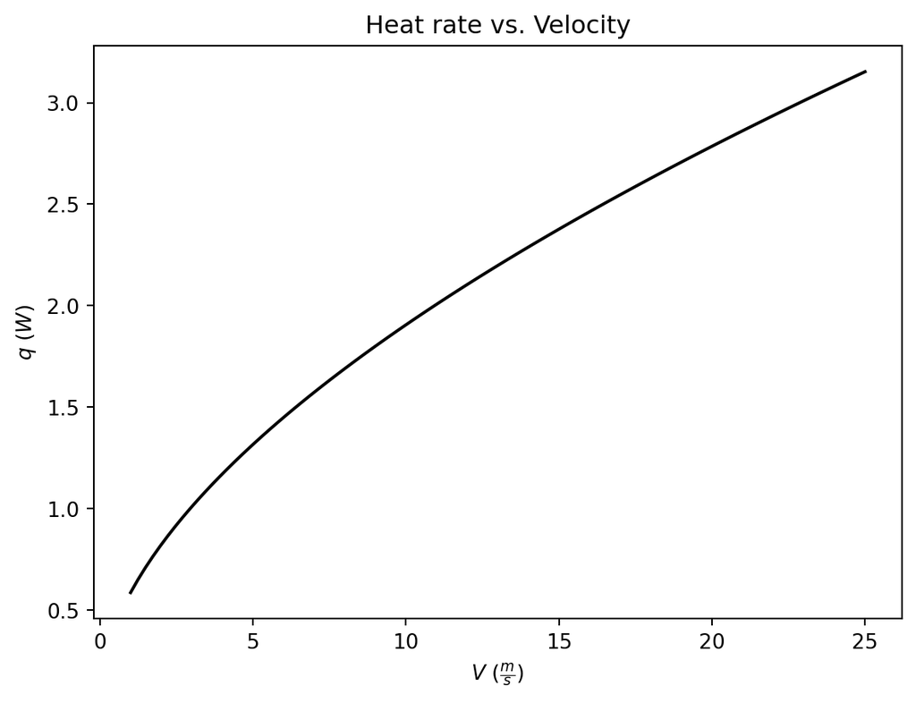

```python
fig, ax = plt.subplots(1, 1)

ax.plot(Vvals, qvals, color='k')

ax.set_xlabel('$V\\ (\\frac{m}{s})$')
ax.set_ylabel('$q\\ (W)$')

ax.set_title('Heat rate vs. Velocity')

plt.show()
```